# ACE and Food Insecurity

Descriptives Tables and Figures

Author

Noah Gibson

Published

October 22, 2023

The purpose of this document is to create ~final weighted descriptives and tables.

To create `ace_fi_tidy_v2.csv`, I merged two PSID datasets: the Childhood Retrospective Circumstances Study (collected in 2014) and the 2015 Individual- and Family-level datasets. `ace_fi_tidy_v2.csv` includes three types of individuals: reference persons, spouses, and long-term partners (see `ace_fi_tidy_v2.qmd` for code). I also downloaded the 2017 and 2019 PSID waves but am still trying to figure out if we need them.

## 1 Download/clean data

Here is a summary of our variables of interest:

Data summary

| Name | d |
| --- | --- |
| Number of rows | 4977 |
| Number of columns | 39 |
| _______________________ |  |
| Column type frequency: |  |
| character | 2 |
| numeric | 37 |
| ________________________ |  |
| Group variables | None |

**Variable type: character**

| skim_variable | n_missing | complete_rate | min | max | empty | n_unique | whitespace |
| --- | --- | --- | --- | --- | --- | --- | --- |
| health_status | 4 | 1 | 4 | 9 | 0 | 5 | 0 |
| race_eth | 4 | 1 | 5 | 8 | 0 | 4 | 0 |

**Variable type: numeric**

| skim_variable | n_missing | complete_rate | mean | sd | p0 | p25 | p50 | p75 | p100 | hist |
| --- | --- | --- | --- | --- | --- | --- | --- | --- | --- | --- |
| id | 0 | 1.00 | 2874737.19 | 2122347.95 | 4006.00 | 1163007.00 | 2225032.00 | 5306032.00 | 6872183.00 | ▇▇▂▂▆ |
| ace_divorce | 159 | 0.97 | 0.13 | 0.33 | 0.00 | 0.00 | 0.00 | 0.00 | 1.00 | ▇▁▁▁▁ |
| ace_health | 19 | 1.00 | 0.04 | 0.20 | 0.00 | 0.00 | 0.00 | 0.00 | 1.00 | ▇▁▁▁▁ |
| ace_school_health | 47 | 0.99 | 0.08 | 0.27 | 0.00 | 0.00 | 0.00 | 0.00 | 1.00 | ▇▁▁▁▁ |
| ace_dad_unemp_0_5 | 217 | 0.96 | 0.09 | 0.29 | 0.00 | 0.00 | 0.00 | 0.00 | 1.00 | ▇▁▁▁▁ |
| ace_dad_unemp_6_12 | 212 | 0.96 | 0.12 | 0.32 | 0.00 | 0.00 | 0.00 | 0.00 | 1.00 | ▇▁▁▁▁ |
| ace_dad_unemp_13_16 | 195 | 0.96 | 0.11 | 0.32 | 0.00 | 0.00 | 0.00 | 0.00 | 1.00 | ▇▁▁▁▁ |
| ace_mom_unemp_0_5 | 179 | 0.96 | 0.15 | 0.36 | 0.00 | 0.00 | 0.00 | 0.00 | 1.00 | ▇▁▁▁▂ |
| ace_mom_unemp_6_12 | 175 | 0.96 | 0.18 | 0.39 | 0.00 | 0.00 | 0.00 | 0.00 | 1.00 | ▇▁▁▁▂ |
| ace_mom_unemp_13_16 | 171 | 0.97 | 0.17 | 0.37 | 0.00 | 0.00 | 0.00 | 0.00 | 1.00 | ▇▁▁▁▂ |
| ace_fin_0_5 | 191 | 0.96 | 0.35 | 0.48 | 0.00 | 0.00 | 0.00 | 1.00 | 1.00 | ▇▁▁▁▅ |
| ace_fin_6_12 | 153 | 0.97 | 0.37 | 0.48 | 0.00 | 0.00 | 0.00 | 1.00 | 1.00 | ▇▁▁▁▅ |
| ace_fin_13_16 | 150 | 0.97 | 0.35 | 0.48 | 0.00 | 0.00 | 0.00 | 1.00 | 1.00 | ▇▁▁▁▅ |
| ace_welfare_0_5 | 123 | 0.98 | 0.15 | 0.36 | 0.00 | 0.00 | 0.00 | 0.00 | 1.00 | ▇▁▁▁▂ |
| ace_welfare_6_12 | 122 | 0.98 | 0.18 | 0.38 | 0.00 | 0.00 | 0.00 | 0.00 | 1.00 | ▇▁▁▁▂ |
| ace_welfare_13_16 | 119 | 0.98 | 0.15 | 0.36 | 0.00 | 0.00 | 0.00 | 0.00 | 1.00 | ▇▁▁▁▂ |
| ace_fin_comp | 92 | 0.98 | 0.21 | 0.41 | 0.00 | 0.00 | 0.00 | 0.00 | 1.00 | ▇▁▁▁▂ |
| ace_lonely_6_12 | 57 | 0.99 | 0.21 | 0.41 | 0.00 | 0.00 | 0.00 | 0.00 | 1.00 | ▇▁▁▁▂ |
| ace_lonely_13_16 | 123 | 0.98 | 0.22 | 0.42 | 0.00 | 0.00 | 0.00 | 0.00 | 1.00 | ▇▁▁▁▂ |
| ace_repeat_school | 41 | 0.99 | 0.15 | 0.36 | 0.00 | 0.00 | 0.00 | 0.00 | 1.00 | ▇▁▁▁▂ |
| ace_bullied_school_6_12 | 38 | 0.99 | 0.25 | 0.43 | 0.00 | 0.00 | 0.00 | 0.00 | 1.00 | ▇▁▁▁▂ |
| ace_bullied_school_13_16 | 136 | 0.97 | 0.19 | 0.39 | 0.00 | 0.00 | 0.00 | 0.00 | 1.00 | ▇▁▁▁▂ |
| ace_bullied_out_6_12 | 75 | 0.98 | 0.15 | 0.35 | 0.00 | 0.00 | 0.00 | 0.00 | 1.00 | ▇▁▁▁▂ |
| ace_bullied_out_13_16 | 152 | 0.97 | 0.11 | 0.31 | 0.00 | 0.00 | 0.00 | 0.00 | 1.00 | ▇▁▁▁▁ |
| ace_school_happy_6_12 | 68 | 0.99 | 0.12 | 0.32 | 0.00 | 0.00 | 0.00 | 0.00 | 1.00 | ▇▁▁▁▁ |
| ace_school_happy_13_16 | 150 | 0.97 | 0.15 | 0.35 | 0.00 | 0.00 | 0.00 | 0.00 | 1.00 | ▇▁▁▁▂ |
| ace_school_safety_6_12 | 67 | 0.99 | 0.10 | 0.30 | 0.00 | 0.00 | 0.00 | 0.00 | 1.00 | ▇▁▁▁▁ |
| ace_school_safety_13_16 | 159 | 0.97 | 0.10 | 0.30 | 0.00 | 0.00 | 0.00 | 0.00 | 1.00 | ▇▁▁▁▁ |
| age | 0 | 1.00 | 48.78 | 16.37 | 19.00 | 35.00 | 48.00 | 61.00 | 96.00 | ▆▇▇▃▁ |
| snap | 3 | 1.00 | 0.18 | 0.38 | 0.00 | 0.00 | 0.00 | 0.00 | 1.00 | ▇▁▁▁▂ |
| income | 0 | 1.00 | 74651.41 | 80678.75 | 0.00 | 26200.00 | 54643.00 | 99800.00 | 2061600.00 | ▇▁▁▁▁ |
| educ | 42 | 0.99 | 13.78 | 2.33 | 0.00 | 12.00 | 14.00 | 16.00 | 17.00 | ▁▁▁▆▇ |
| weight_2015 | 0 | 1.00 | 25.65 | 22.00 | 0.16 | 7.15 | 20.29 | 35.57 | 142.78 | ▇▃▂▁▁ |
| female | 0 | 1.00 | 0.35 | 0.48 | 0.00 | 0.00 | 0.00 | 1.00 | 1.00 | ▇▁▁▁▅ |
| fs | 0 | 1.00 | 0.14 | 0.35 | 0.00 | 0.00 | 0.00 | 0.00 | 1.00 | ▇▁▁▁▂ |
| log_income | 0 | 1.00 | 4.63 | 0.70 | 0.00 | 4.42 | 4.74 | 5.00 | 6.31 | ▁▁▁▇▂ |
| cum_ace | 1050 | 0.79 | 4.36 | 4.11 | 0.00 | 1.00 | 3.00 | 7.00 | 24.00 | ▇▃▁▁▁ |

## 2 Descriptive table by class (ace variables)

Here is a breakdown of responses to ACE questions by class membership. I think this serves as a nice “Table 1” in our paper.

Weighted descriptive statistics for all variables (n = 3,927)

| **Variable** | **Limited** (56.4%)<sup>1</sup> | **Emotional** (9.33%)<sup>1</sup> | **Financial** (10.5%)<sup>1</sup> | **High** (7.88%)<sup>1</sup> | **Parental** (10.6%)<sup>1</sup> | **School-related** (5.21%)<sup>1</sup> |
| --- | --- | --- | --- | --- | --- | --- |
| ace_divorce | 5.7% | 8.0% | 11.1% | 14.2% | 29.5% | 15.7% |
| ace_health | 1.3% | 5.4% | 7.6% | 10.0% | 3.8% | 19.4% |
| ace_school_health | 6.6% | 10.3% | 9.8% | 16.7% | 10.1% | 17.0% |
| ace_dad_unemp |  |  |  |  |  |  |
| 0 | 93.1% | 92.2% | 77.2% | 54.0% | 40.6% | 87.0% |
| 1 | 6.3% | 6.7% | 6.6% | 18.6% | 36.3% | 8.3% |
| 2 | 0.2% | 0.1% | 6.5% | 13.2% | 15.7% | 3.7% |
| 3 | 0.4% | 1.0% | 9.7% | 14.2% | 7.4% | 0.9% |
| ace_mom_unemp |  |  |  |  |  |  |
| 0 | 90.8% | 88.3% | 69.7% | 41.6% | 39.6% | 81.3% |
| 1 | 5.6% | 7.2% | 6.3% | 17.3% | 34.0% | 9.8% |
| 2 | 1.5% | 0.9% | 8.7% | 19.9% | 19.4% | 3.8% |
| 3 | 2.1% | 3.6% | 15.3% | 21.2% | 7.0% | 5.1% |
| ace_fin |  |  |  |  |  |  |
| 0 | 78.2% | 65.8% | 0.0% | 0.0% | 12.0% | 70.2% |
| 1 | 11.4% | 20.2% | 0.0% | 1.7% | 47.1% | 14.3% |
| 2 | 3.9% | 8.6% | 10.6% | 22.1% | 30.1% | 10.2% |
| 3 | 6.4% | 5.4% | 89.4% | 76.1% | 10.8% | 5.4% |
| ace_welfare |  |  |  |  |  |  |
| 0 | 97.7% | 95.7% | 58.6% | 55.1% | 62.3% | 94.2% |
| 1 | 0.8% | 2.0% | 7.9% | 8.3% | 25.9% | 4.3% |
| 2 | 0.9% | 1.3% | 10.7% | 17.5% | 8.7% | 0.1% |
| 3 | 0.6% | 1.0% | 22.8% | 19.1% | 3.2% | 1.4% |
| ace_fin_comp | 2.2% | 4.0% | 86.8% | 79.5% | 20.6% | 7.8% |
| ace_lonely |  |  |  |  |  |  |
| 0 | 84.5% | 38.6% | 72.1% | 36.3% | 64.3% | 42.7% |
| 1 | 7.6% | 29.2% | 15.8% | 20.3% | 17.8% | 13.0% |
| 2 | 7.9% | 32.2% | 12.1% | 43.3% | 17.9% | 44.4% |
| ace_repeat_school | 7.7% | 13.9% | 18.4% | 17.6% | 16.0% | 15.3% |
| ace_bullied_school |  |  |  |  |  |  |
| 0 | 92.5% | 6.0% | 85.5% | 6.8% | 75.6% | 0.0% |
| 1 | 4.3% | 78.0% | 10.9% | 35.1% | 19.4% | 0.0% |
| 2 | 3.2% | 16.1% | 3.6% | 58.1% | 5.0% | 100.0% |
| ace_bullied_out |  |  |  |  |  |  |
| 0 | 98.1% | 52.1% | 98.7% | 22.8% | 95.0% | 14.8% |
| 1 | 1.2% | 45.7% | 1.3% | 34.6% | 4.6% | 13.7% |
| 2 | 0.7% | 2.2% | 0.0% | 42.6% | 0.4% | 71.5% |
| ace_school_happy |  |  |  |  |  |  |
| 0 | 93.0% | 68.3% | 86.1% | 52.5% | 82.6% | 64.0% |
| 1 | 2.9% | 22.3% | 6.6% | 20.7% | 10.1% | 14.6% |
| 2 | 4.1% | 9.4% | 7.2% | 26.8% | 7.3% | 21.4% |
| ace_school_safety |  |  |  |  |  |  |
| 0 | 97.7% | 65.5% | 93.8% | 56.3% | 90.7% | 58.4% |
| 1 | 1.5% | 32.0% | 3.9% | 24.3% | 8.2% | 12.9% |
| 2 | 0.8% | 2.5% | 2.3% | 19.4% | 1.2% | 28.7% |
| cum_ace | 1.4 (1.4) | 4.6 (1.9) | 7.3 (2.7) | 12.4 (3.4) | 5.8 (2.1) | 7.7 (2.4) |

<sup>1</sup> %; Mean (SD)

## 3 Descriptive table by class (controls)

And here are our control variables by class.

Weighted descriptive statistics for all variables (n = 3,927)

| **Variable** | **Limited** (56.4%)<sup>1</sup> | **Emotional** (9.33%)<sup>1</sup> | **Financial** (10.5%)<sup>1</sup> | **High** (7.88%)<sup>1</sup> | **Parental** (10.6%)<sup>1</sup> | **School-related** (5.21%)<sup>1</sup> |
| --- | --- | --- | --- | --- | --- | --- |
| fs | 6.0% | 10.5% | 12.3% | 21.3% | 8.8% | 21.0% |
| age | 55.8 (16.7) | 48.9 (14.9) | 55.7 (16.8) | 49.7 (16.6) | 48.6 (17.1) | 48.7 (14.4) |
| income | 89,422.0 (85,168.5) | 82,732.0 (148,787.6) | 75,353.0 (83,557.8) | 65,613.2 (56,910.6) | 77,926.3 (85,898.3) | 66,388.7 (56,803.9) |
| educ | 14.4 (2.2) | 14.9 (2.2) | 13.4 (2.4) | 13.8 (2.3) | 13.9 (2.3) | 14.2 (2.2) |
| Unknown | 376 | 44 | 118 | 60 | 41 | 3 |
| snap | 7.2% | 9.5% | 13.3% | 18.7% | 12.3% | 15.8% |
| Unknown | 34 | 0 | 0 | 0 | 0 | 0 |
| health_status |  |  |  |  |  |  |
| poor | 3.1% | 3.7% | 7.2% | 4.9% | 4.5% | 7.9% |
| excellent | 18.9% | 16.4% | 13.8% | 6.9% | 14.5% | 11.5% |
| fair | 9.3% | 11.3% | 14.7% | 15.6% | 10.7% | 15.9% |
| good | 29.1% | 28.1% | 34.0% | 35.8% | 28.7% | 36.3% |
| very good | 39.6% | 40.5% | 30.2% | 36.7% | 41.6% | 28.3% |
| Unknown | 30 | 0 | 3 | 2 | 0 | 0 |
| female | 32.1% | 37.0% | 27.7% | 40.5% | 32.7% | 30.5% |
| race_eth |  |  |  |  |  |  |
| White | 83.0% | 83.3% | 74.7% | 74.4% | 70.9% | 78.7% |
| Black | 10.7% | 8.0% | 14.7% | 16.8% | 14.5% | 11.5% |
| Hispanic | 3.9% | 5.6% | 7.6% | 6.8% | 11.4% | 4.3% |
| Other | 2.3% | 3.2% | 3.0% | 2.0% | 3.2% | 5.5% |
| Unknown | 20 | 0 | 0 | 0 | 37 | 0 |

<sup>1</sup> %; Mean (SD)

## 4 Model comparisons

As I see it, one key contribution of our paper is improving on cumulative measures of ACEs. So I think it is important to highlight how our approach differs from cumulative measures. This might not be exactly what we want to include in our paper, but I think it is at least interesting to look at.

Let’s compare three models to see which is most statistically informative. Model 1 includes all controls but does not include information on adversity. Model 2 includes all controls and class membership. Model 3 includes all controls and a cumulative measure of adversity.

|  | (1) | (2) | (3) |
| --- | --- | --- | --- |
| (Intercept) | 3.623*** | 3.137*** | 2.670** |
|  | (0.938) | (0.943) | (0.959) |
| age | -0.032*** | -0.030*** | -0.028*** |
|  | (0.006) | (0.006) | (0.006) |
| log_income | -0.439** | -0.419** | -0.427** |
|  | (0.134) | (0.135) | (0.137) |
| female | 0.169 | 0.155 | 0.153 |
|  | (0.187) | (0.189) | (0.189) |
| snap | 1.768*** | 1.752*** | 1.726*** |
|  | (0.220) | (0.223) | (0.223) |
| race_ethBlack | -0.004 | 0.043 | 0.011 |
|  | (0.228) | (0.233) | (0.228) |
| race_ethHispanic | 0.021 | 0.042 | -0.013 |
|  | (0.379) | (0.364) | (0.364) |
| race_ethOther | 0.120 | 0.031 | 0.102 |
|  | (0.477) | (0.499) | (0.487) |
| educ | -0.100** | -0.103** | -0.082* |
|  | (0.039) | (0.040) | (0.039) |
| health_statusexcellent | -2.672*** | -2.545*** | -2.517*** |
|  | (0.448) | (0.456) | (0.444) |
| health_statusfair | -0.522 | -0.521 | -0.484 |
|  | (0.377) | (0.391) | (0.377) |
| health_statusgood | -1.094** | -1.058** | -1.016** |
|  | (0.356) | (0.372) | (0.361) |
| health_statusvery good | -2.044*** | -1.945*** | -1.944*** |
|  | (0.371) | (0.385) | (0.374) |
| class_membershipsEmotional |  | 0.408 |  |
|  |  | (0.296) |  |
| class_membershipsFinancial |  | 0.375 |  |
|  |  | (0.250) |  |
| class_membershipsHigh |  | 0.891*** |  |
|  |  | (0.266) |  |
| class_membershipsParental |  | -0.123 |  |
|  |  | (0.342) |  |
| class_membershipsSchool-related |  | 0.893** |  |
|  |  | (0.283) |  |
| cum_ace |  |  | 0.076*** |
|  |  |  | (0.019) |
| Num.Obs. | 3883 | 3883 | 3883 |
| R2 | 0.266 | 0.280 | 0.278 |
| R2 Adj. | 0.264 | 0.277 | 0.275 |
| AIC | 1817.2 | 1801.9 | 1792.6 |
| BIC | 1888.6 | 1896.6 | 1869.4 |
| Log.Lik. | -886.473 | -869.797 | -872.731 |
| RMSE | 0.31 | 0.30 | 0.30 |

There aren’t huge differences between models in terms of BIC and AIC, so we can’t really make the case that our approach is improving model fit. This makes senses though, given that a cumulative measure of ACE includes more variation than class membership.

## 5 Cumulative ace measure by class

One key way to motivate our paper is by arguing that certain ACE variables are more negatively associated with food insecurity than others. For instance, based on the graph below, previous papers would argue that the `High` class has higher rates of food insecurity than the `School-related` and `Financial` classes. But we find that the `School-related` class has food insecurity rate that is similar to `High`.

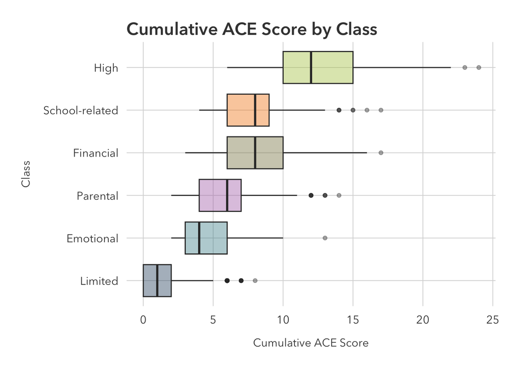

> Do the boxplots or density ridges look better?

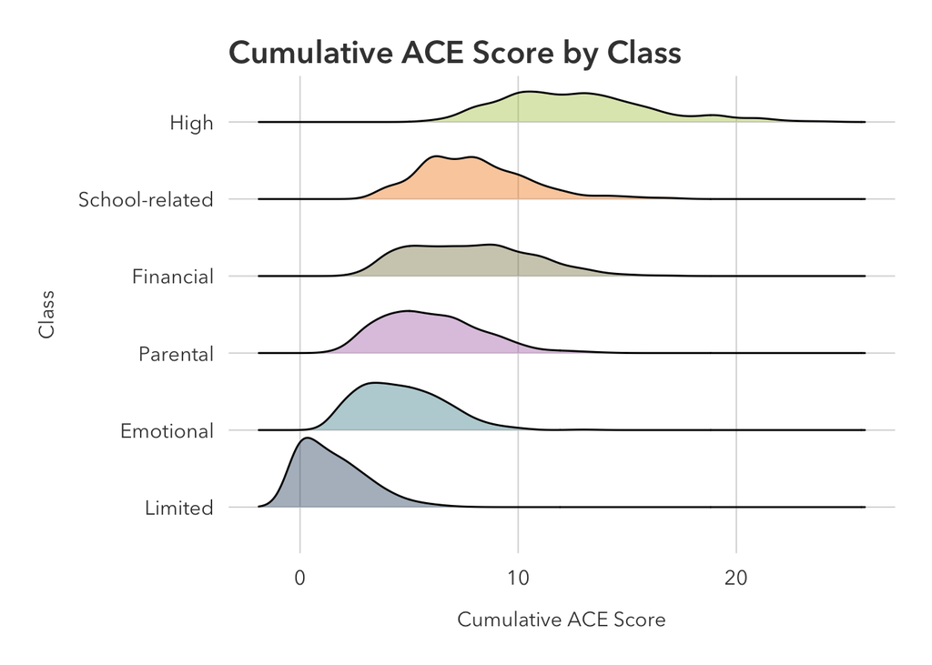

## 6 Cumulative finacial ACE variables by class

Interestingly, the `School-related` class has low levels of financial adversity as children (I created a cumulative ACE measure just based on the three financial ACE variables). Is it worth including a few graphs like this in our paper?

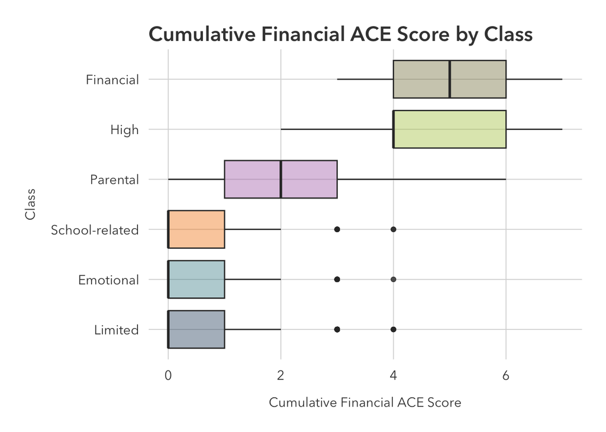

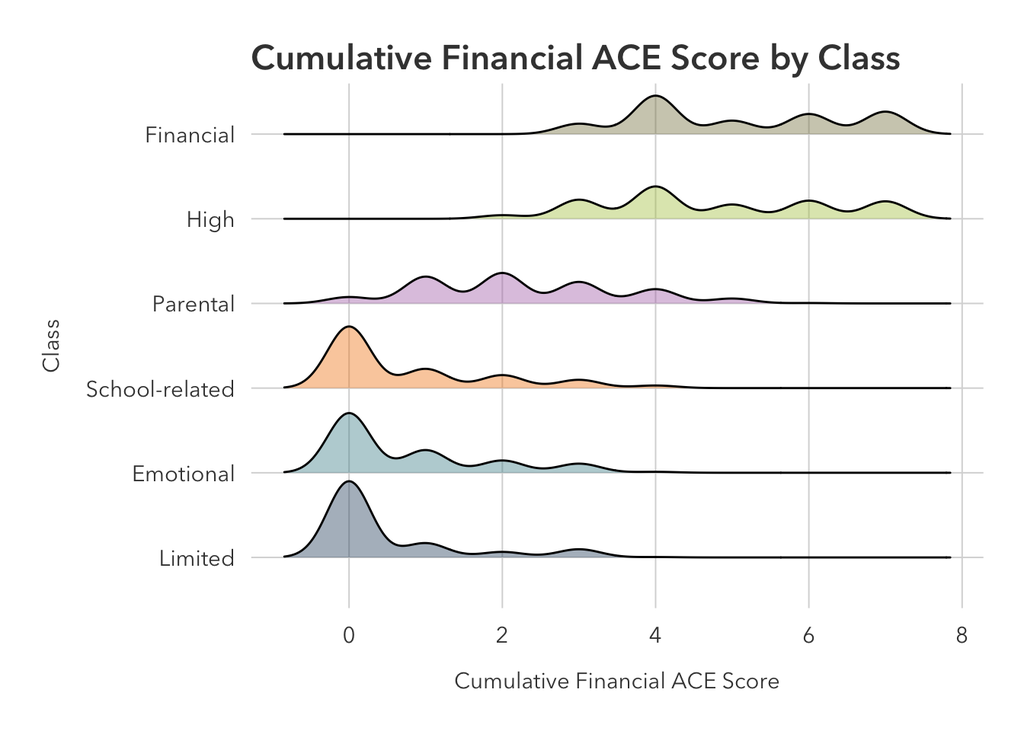

## 7 Cumulative bullying/loneliness ACE variables by class

Now let’s take a look at just bullying/loneliness ACE variables.

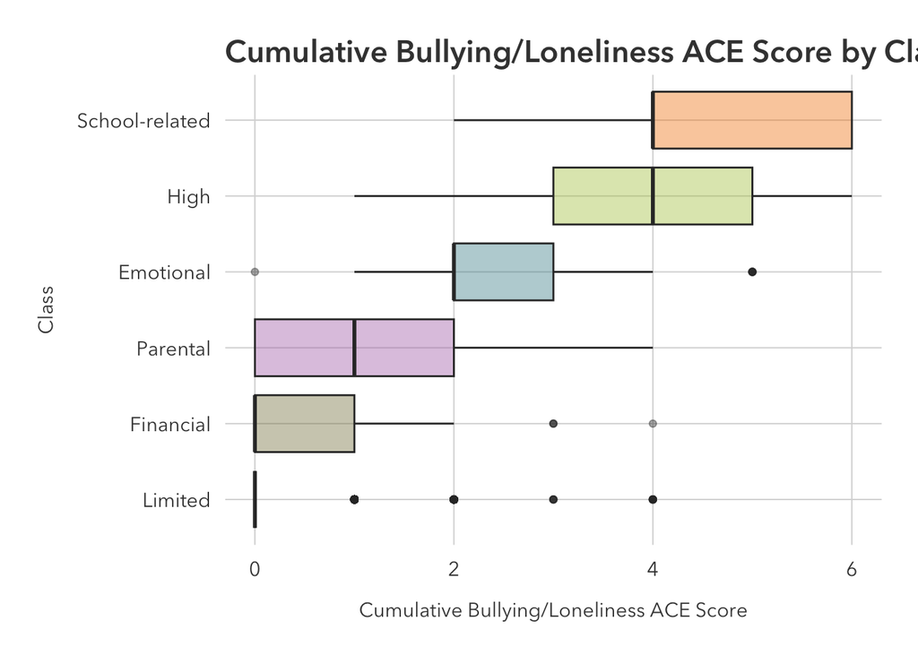

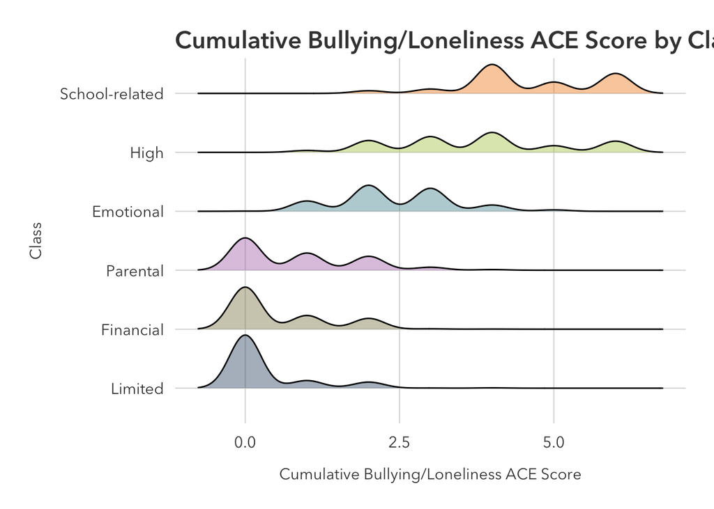

## 8 Food insecurity rates by class

Moving on to our outcome, the `School-related` class has a food insecurity rate that is similar to `High`, which I think is the most interesting finding in our results. (The red line is the average food insecurity rate for the sample.)

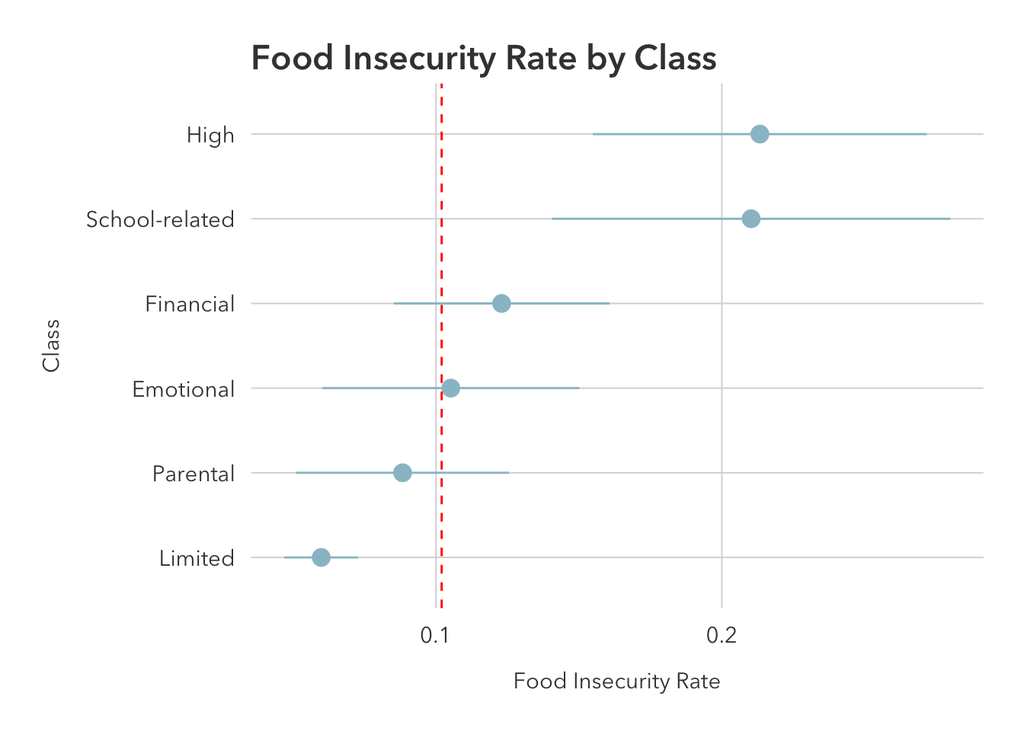

> Why is the food insecurity rate so high for the `School-related` group?

I think we need to try to unpack this a bit in our paper. We know that the `School-related` group had 1.) low levels of financial adversity, and 2.) high levels of emotional adversity. Point 1 leads me to think that we might be able to connect this to literature on coping mechanisms. Is it possible that individuals that struggled financially in childhood have better coping strategies for financial precarity in adulthood? Point 2 makes me think of networks. I know some literature on food insecurity and social networks. Could it be that people in the `School-related` groups have fewer social resources?

## 9 Predicted probabilities by class

Here is a look at predicted probabilities (which adjust for controls). The `School-related` class has a high predicted probability of food insecurity even when adjusting for key demographic variables in 2015.

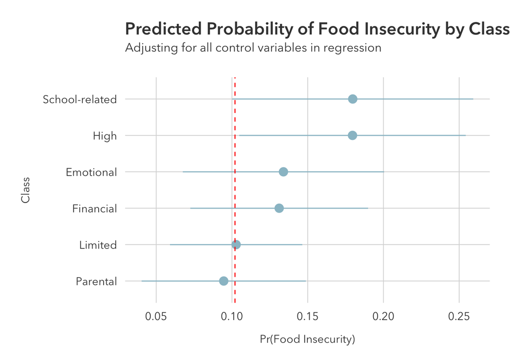